# Drug toxicity

Artem Sokolov

## Nuclei counts from a Deep Dye Drop assay

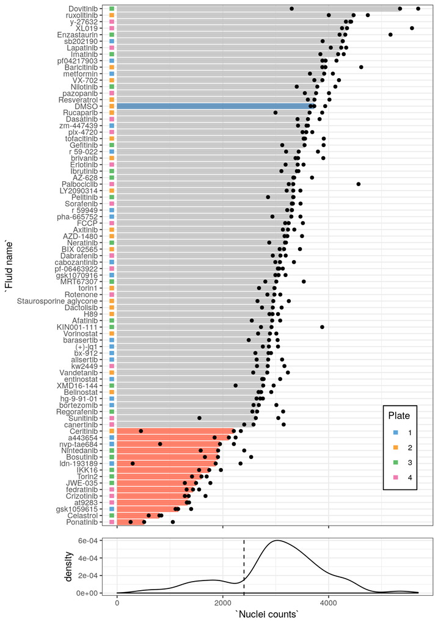

An overview of the raw nuclei counts values, with individual replicates shown as black points and their averages as bars. The overall distrbution has a natural break around 2,400 nuclei, which we use to define a toxicity threshold. All drugs that fall below the threshold are highlighted in red, with DMSO shown in blue. Plate index is included for reference.

## Plate batch effect

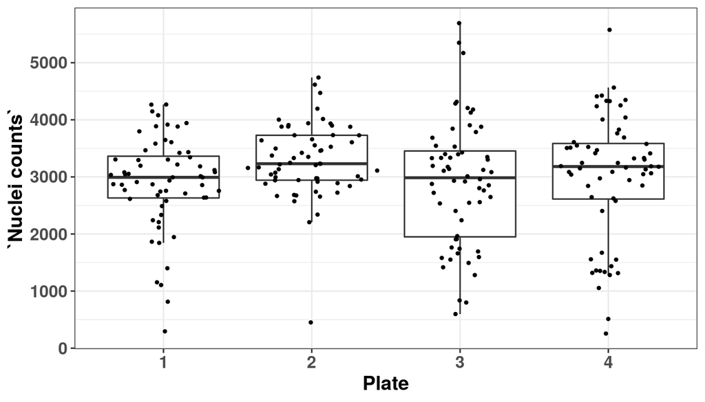

The distribution of nuclei counts across each of the four plates. There is no obvious plate-based batch effect.

## Correlation with transcript count from DGE

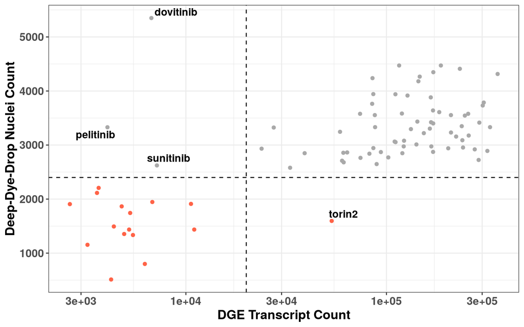

Nuclei counts from the Deep-Dye-Drop assay plotted against transcript counts from DGE. For the vast majority of drugs, there’s a strong agreement between toxic and non-toxic groupings. The exceptions include three RTK inihibitors dovitinib, pelitinib, and sunitinib, as well as Torin2.

## Well edge effects

### Toxicity: nuclei counts

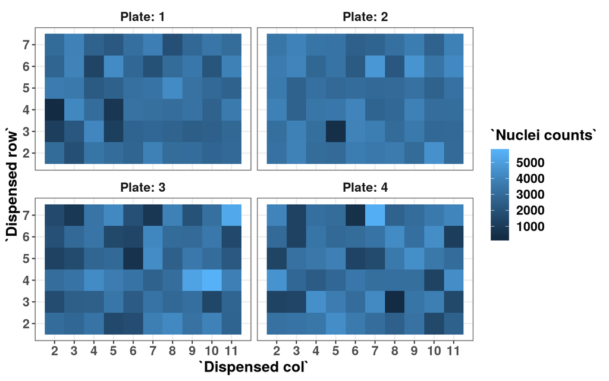

Layout of the four plates used in toxicity experiments. The outermost wells were not used. From the plot, we observe that there is no obvious edge effect for the remaining wells.

### DGE: total transcript counts

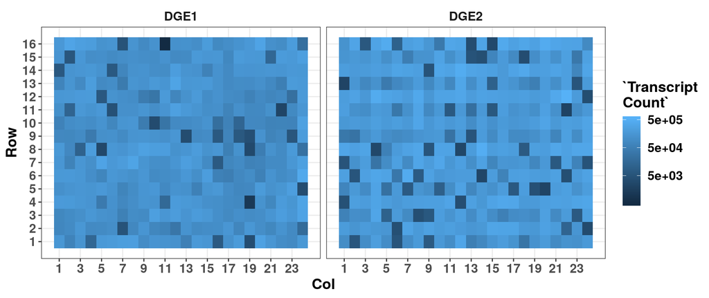

Similar plot for DGE plates also reveals no obvious edge effect.

### Predictive performance

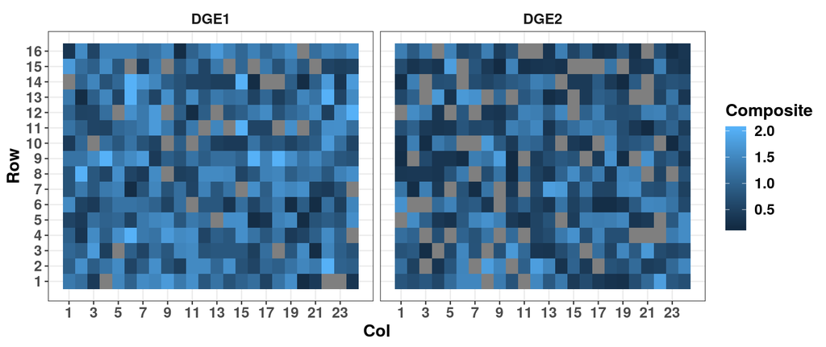

Finally, we ensure that poor-performing drugs are not localized to edge wells.